# Partisan YouTube Rhetorical Strategy and Moral Signaling -Technical Appendix

## Overview

### Package loading

First we load the necessary packages for text processing.

```r
library(cluster)
library(dendextend)
library(ggdendro)
library(factoextra)
library(quanteda)
library(tidyverse)
library(nFactors)
library(texreg)
source("resources/functions/keyness_functions.R")
source("resources/functions/mda_functions.R")
source("resources/functions/helper_functions.R")
```

### Load and combine the main data sources

#### DocuScope Tag Breakdown

We have the breakdown of the DocuScope tagging below. The unique index is the token_csv_name, representing a unique scraped youtube transcript. There are over 2500 rhetorical categories at the most detailed level. In the classification analysis I agglomerate them to make the data less sparse and easier to generalize.

```r
df_info <- read.csv("data/docuscope/DIMENSION_cleaned.csv",stringsAsFactors = F)
head(df_info)
```

|  | text_name | text_key | token_csv_name | chunk_index | X.UNRECOGNIZED | X.UNTAGGED | X.BLACKLISTED | AcadCARSDiscussion | AcadCARSResults | AcademicAnatomy | AcademicArt | AcademicArtArchitecture | AcademicArtLanguageDrama | AcademicArtLanguageLiterature | AcademicArtists | AcademicCARSIntroMove1Background | AcademicCARSIntroMove1Centrality | AcademicCARSIntroMove2NicheGaps | AcademicCARSIntroMove2NicheGapsLimitations | AcademicCARSIntroMove3NicheAnnounceResearchToBePresented | AcademicCARSIntroMove3PurposeMain | AcademicCARSMethods | AcademicCognates | AcademicControversy | AcademicDimensionGeneral | AcademicDimensionGeneralWarehousedByLetter | AcademicDiscourseExplanatory | AcademicDiscourseMethod | AcademicEducation | … |
| --- | --- | --- | --- | --- | --- | --- | --- | --- | --- | --- | --- | --- | --- | --- | --- | --- | --- | --- | --- | --- | --- | --- | --- | --- | --- | --- | --- | --- | --- | --- |
| 1 | YR9hZ8tK-jo.txt | YR9hZ8tKjo | YR9hZ8tKjo-tokens.csv | 0 | 0.2092050 | 2.3012552 | 0 | 0 | 0 | 0 | 0 | 0 | 0 | 0.000000 | 0 | 0 | 0 | 0 | 0 | 0.000000 | 0 | 0 | 0 | 0 | 0.8368201 | 1.464435 | 0 | 0.000000 | 0 | … |
| 2 | klmf9UwvcUE.txt | klmf9UwvcUE | klmf9UwvcUE-tokens.csv | 0 | 0.0000000 | 3.3707865 | 0 | 0 | 0 | 0 | 0 | 0 | 0 | 1.123596 | 0 | 0 | 0 | 0 | 0 | 1.123596 | 0 | 0 | 0 | 0 | 0.0000000 | 2.247191 | 0 | 0.000000 | 0 | … |
| 3 | TSFInl-4lM4.txt | TSFInl4lM4 | TSFInl4lM4-tokens.csv | 0 | 0.0000000 | 0.0000000 | 0 | 0 | 0 | 0 | 0 | 0 | 0 | 0.000000 | 0 | 0 | 0 | 0 | 0 | 0.000000 | 0 | 0 | 0 | 0 | 0.0000000 | 2.777778 | 0 | 0.000000 | 0 | … |
| 4 | kSh2qVm4IKM.txt | kSh2qVm4IKM | kSh2qVm4IKM-tokens.csv | 0 | 0.0000000 | 3.0303030 | 0 | 0 | 0 | 0 | 0 | 0 | 0 | 0.000000 | 0 | 0 | 0 | 0 | 0 | 0.000000 | 0 | 0 | 0 | 0 | 0.0000000 | 0.000000 | 0 | 0.000000 | 0 | … |
| 5 | Szv4Vnuu7sE.txt | Szv4Vnuu7sE | Szv4Vnuu7sE-tokens.csv | 0 | 0.3032600 | 0.9855951 | 0 | 0 | 0 | 0 | 0 | 0 | 0 | 0.000000 | 0 | 0 | 0 | 0 | 0 | 0.000000 | 0 | 0 | 0 | 0 | 0.1516300 | 1.819560 | 0 | 0.000000 | 0 | … |
| 6 | 85Ub-uPCwuM.txt | 85UbuPCwuM | 85UbuPCwuM-tokens.csv | 0 | 0.2628121 | 2.7595269 | 0 | 0 | 0 | 0 | 0 | 0 | 0 | 0.000000 | 0 | 0 | 0 | 0 | 0 | 0.000000 | 0 | 0 | 0 | 0 | 0.5256242 | 1.708279 | 0 | 0.131406 | 0 | … |

#### Channel level

The channel data contains channel level data, including the two primary variables of interest: Political Leaning and Media Type.

```r
df_channels <- read.csv('data/youtube/compiled/COMPILED channel_data_20191212.csv', stringsAsFactors=F)
head(df_channels)
```

|  | X | channelId | viewCount | commentCount | subscriberCount | videoCount | title | description | customUrl | publishedAt | Political.Leaning | Type |
| --- | --- | --- | --- | --- | --- | --- | --- | --- | --- | --- | --- | --- |
| 1 | 0 | UC-3jIAlnQmbbVMV6gR7K8aQ | 285232016 | 0 | 7.16e+05 | 13598 | The Majority Report w/ Sam Seder | The Majority Report is a daily, political talk show at majority.fm live at 12PM ET. Call the show after 12:30PM ET 646-257-3920. Available on Itunes or the site as a podcast. | samseder | 2010-05-25T02:04:46.000Z | Liberal | Vlog |
| 2 | 1 | UC-CDQ-MPUdBWcjB7SrD1HZA | 250046 | 0 | 1.10e+04 | 30 | anactualjoke | Anarchist Trans Girl. She/Her. Making Video Essays and hot takes. | anactualjoke | 2015-02-10T16:57:10.000Z | Left | Vlog |
| 3 | 2 | UC-lHJZR3Gqxm24_Vd_AJ5Yw | 24093884864 | 0 | 1.02e+08 | 4027 | PewDiePie | I make videos. | pewdiepie | 2010-04-29T10:54:00.000Z | not political | Vlog |
| 4 | 3 | UC-yewGHQbNFpDrGM0diZOLA | 303324704 | 0 | 9.67e+05 | 1180 | Sargon of Akkad | English liberal. \n\nPaypal tip jar address: intotheaether(at)hotmail.co.uk\n\nNOTE: Please do not contact the subjects of any of my videos, ever. | sargonofakkad | 2010-10-13T22:38:04.000Z | Right | Vlog |
| 5 | 4 | UC0KaZd_ki4l2EUc1GY9u5Ew | 6749437 | 0 | 7.23e+04 | 108 | KyleKallgrenBHH | A mildly immature look at movies and movie-related nonsense. | oancitizen | 2006-09-15T05:00:44.000Z | Left | Vlog |
| 6 | 5 | UC0aVoboXBUx2-tVIWHc3W2Q | 136772966 | 0 | 8.50e+05 | 810 | MILO | The most fabulous New York Times Best Selling supervillain on the internet.\n\nBLOG: https://Dangerous.com\nBUY: http://DangerousBoutique.com\nWATCH: http://Dangerous.com/join\nINFO: https://MILO-inc.… | yiannopoulosm | 2009-04-24T17:23:25.000Z | Right | Vlog |

#### Video Data

The video data has video level data, like publish date and description for each video Id. It also has the Political Leaning and Media Type for playlist level designation.

```r
df_video <- read.csv('data/youtube/compiled/COMPILED video_data_20191212.csv',stringsAsFactors = F)
head(df_video)
```

|  | X | playlistName | videoId | channelId | playlistId | channelTitle | date.scraped | description | description.scraped | dislikes.scraped | duration.scraped | likes.scraped | publishedAt | title | title.scraped | transcript.scraped | views.scraped | Political.Leaning | Type |
| --- | --- | --- | --- | --- | --- | --- | --- | --- | --- | --- | --- | --- | --- | --- | --- | --- | --- | --- | --- |
| 1 | 0 | Acronym TV | -L5-PNCzJfc | UC17knbFWwBQOSaLCiTO_5jw | UU17knbFWwBQOSaLCiTO_5jw | Acronym TV | Sep 26, 2015 | Full episode - \n1. Bill Maher told his Real Time with Bill Maher audience recently that the homemade clock that got 14- year old Ahmed Mohamed handcuffed and arrested from his school actually â\200œl… | Full episode - \n1. Bill Maher told his Real Time with Bill Maher audience recently that the homemade clock that got 14- year old Ahmed Mohamed handcuffed and arrested from his school actually â\200œl… | 15 dislikes | NA | 59 likes | 2015-09-26T15:43:52.000Z | Acronym TV 9.26.15 â\200“ Bill Maher, Refugee Crisis and Avoiding Bar Fights [41] | Acronym TV 9.26.15 â\200“ Bill Maher, Refugee Crisis and Avoiding Bar Fights [41] | True | 997 views |  |  |
| 2 | 1 | Acronym TV | -TV4JWEeh4I | UC17knbFWwBQOSaLCiTO_5jw | UU17knbFWwBQOSaLCiTO_5jw | Acronym TV | Dec 8, 2015 | Subscribe to Acronym TV on YouTube - http://bit.ly/VUl21B\nSupport Acronym TV with a monthly donation https://www.patreon.com/DennisTrainorJr\n\nGet on the mailing list http://www.acronymtv.com/join\n… | Subscribe to Acronym TV on YouTube - http://bit.ly/VUl21B\nSupport Acronym TV with a monthly donation https://www.patreon.com/DennisTrainorJr\n\nGet on the mailing list \n\nFacebook \n\nTwitter \n\n\n… | 2 dislikes | NA | 17 likes | 2015-12-08T22:00:01.000Z | In Paris, Climate Justice Activists Fighting Against All Odds | In Paris, Climate Justice Activists Fighting Against All Odds | True | 381 views |  |  |
| 3 | 2 | Acronym TV | -dUHNAW-tdM | UC17knbFWwBQOSaLCiTO_5jw | UU17knbFWwBQOSaLCiTO_5jw | Acronym TV | Dec 5, 2013 | support Acronym TV http://www.patreon.com/AcronymTV\n\nEarlier this year, as the Edward Snowden story was just starting to break, Michael Grunwald -- the Time magazine senior national correspondent an… | support Acronym TV http://www.patreon.com/AcronymTV\n\nEarlier this year, as the Edward Snowden story was just starting to break, Michael Grunwald -- the Time magazine senior national correspondent an… | 19 dislikes | NA | 662 likes | 2013-12-05T23:03:36.000Z | The Drone That Takes Out Julian Assange | The Drone That Takes Out Julian Assange | True | 10,949 views |  |  |
| 4 | 3 | Acronym TV | -ng0rcay-Oc | UC17knbFWwBQOSaLCiTO_5jw | UU17knbFWwBQOSaLCiTO_5jw | Acronym TV | Sep 30, 2013 | Support Acronym TV with $1/month \nhttp://www.patreon.com/dennistrainorjr\nwords & voice: Pamela Brown\nProduced and edited: Messiah Rhodes\n\nPamela Brown is a member of the national leadership team … | Support Acronym TV with $1/month \nhttp://www.patreon.com/dennistrainorjr\nwords & voice: Pamela Brown\nProduced and edited: Messiah Rhodes\n\nPamela Brown is a member of the national leadership team … | 6 dislikes | NA | 117 likes | 2013-09-30T21:00:02.000Z | Capitalism + Racism = Death \| Pamela Brown \| Resistance Report Segment | Capitalism + Racism = Death \| Pamela Brown \| Resistance Report Segment | True | 2,292 views |  |  |
| 5 | 4 | Acronym TV | -vNcfSycwM8 | UC17knbFWwBQOSaLCiTO_5jw | UU17knbFWwBQOSaLCiTO_5jw | Acronym TV | Sep 7, 2013 | U.S. citizens, as they urge their members of congress to withhold their authority, vested in that body by the Constitution, to wage war, should be adamantly against such a war because it will increase… | U.S. citizens, as they urge their members of congress to withhold their authority, vested in that body by the Constitution, to wage war, should be adamantly against such a war because it will increase… | 8 dislikes | NA | 170 likes | 2013-09-07T20:00:20.000Z | US Intervention In Syria is A Mission Creep with Roots in CIA Led 1953 Iranian coup d'état | US Intervention In Syria is A Mission Creep with Roots in CIA Led 1953 Iranian coup d'état | True | 5,481 views |  |  |
| 6 | 5 | Acronym TV | 09PliT7YopY | UC17knbFWwBQOSaLCiTO_5jw | UU17knbFWwBQOSaLCiTO_5jw | Acronym TV | Sep 25, 2014 | This content is viewer supported: http://www.Patreon.com/AcronymTV\n\n350.org + Avaaz have No Strategy to Win Climate Crisis Struggle â\200“ Arun Gupta\n\nSpeaking to Dennis Trainor, Jr. of Acronym TV… | This content is viewer supported: http://www.Patreon.com/AcronymTV\n\n350.org + Avaaz have No Strategy to Win Climate Crisis Struggle â\200“ Arun Gupta\n\nSpeaking to Dennis Trainor, Jr. of Acronym TV… | No dislikes | NA | 43 likes | 2014-09-25T21:07:26.000Z | 350.org + Avaaz have No Strategy To Win Climate Crisis Struggle â\200“ Arun Gupta | 350.org + Avaaz have No Strategy To Win Climate Crisis Struggle â\200“ Arun Gupta | True | 1,340 views |  |  |

### Combining metadata

We combine the video and channel dataframes to fill in all the non-playlist level political leaning and media type designations, and then clean up redundant columns, and finally incorporate the DocuScope Metadata to reflect the tagged counts.

```r
df_video <- left_join(df_video, df_channels[,c('channelId','Political.Leaning','Type')], by='channelId')
df_video$channelName <- ifelse(df_video$playlistName!="", df_video$playlistName, df_video$channelTitle)
df_video$Political.Leaning <- ifelse(df_video$Political.Leaning.x != '', df_video$Political.Leaning.x, df_video$Political.Leaning.y)
df_video$Type <- ifelse(df_video$Type.x!="", df_video$Type.x, df_video$Type.y)

drop_cols<-c('Type.y','Type.x','Political.Leaning.x','Political.Leaning.y','playlistName','views.scraped','title.scraped','likes.scraped','duration.scraped', 'dislikes.scraped','description.scraped','date.scraped','playlistId','transcript.scraped')
df_video <- dplyr::select(df_video, -one_of(drop_cols))
df_video <- df_video[!duplicated(df_video$videoId),]
df_video$text_name <- paste(df_video$videoId, '.txt',sep='')
df_joined <- inner_join(df_video, df_info, by='text_name')
```

In addition, we want to reduce the variability of the political partisanship, and pigeonhole the more varied poltiical leaning to standardized names.

```r
polt_map <- data.frame(old=c("Left","Moderate","Liberal","not political","alt-right","Right","Conservative" ,"IDW","general","Libertarian","alt-lite", "Progressive"),
                       new=c("Left","Moderate","Liberal","Apolitical","Right","Right","Conservative" ,"Conservative","Moderate","Conservative","Right", "Liberal"))
df_joined$Political.Leaning <- polt_map$new[match(df_joined$Political.Leaning,polt_map$old)]
df_joined <- df_joined[df_joined$X...Tokens. > 20,]

channel_counts <- df_joined %>%
  group_by(channelName, Political.Leaning, Type) %>%
  summarize(words=sum(X...Word.Tokens.),
            punct=sum(X...Punctuation.Tokens.),
            total_tokens=sum(X...Tokens.), files=n())

polt_type_counts <- channel_counts %>% group_by(Type, Political.Leaning) %>%
  summarize(nchannels=n(), files=sum(files), tokens=sum(words))

rm(df_video, df_info, df_channels, polt_map)
```

```r
summarize(polt_type_counts,nchannels=sum(nchannels),
          files=sum(files),
          tokens=sum(tokens))
```

| Type | nchannels | files | tokens |
| --- | --- | --- | --- |
| News Channel | 12 | 2102 | 2238476 |
| Talk Show | 30 | 7461 | 13561282 |
| Vlog | 170 | 26459 | 65597157 |

```r
knitr::kable(rbind.data.frame(polt_type_counts, c(Type='Total', Political.Leaning='Total',
                                                  nchannels=sum(polt_type_counts$nchannels),
                                                  files=sum(polt_type_counts$files),
                                                  tokens=sum(polt_type_counts$tokens))))
```

| Type | Political.Leaning | nchannels | files | tokens |
| --- | --- | --- | --- | --- |
| News Channel | Conservative | 1 | 295 | 230443 |
| News Channel | Left | 1 | 260 | 521516 |
| News Channel | Liberal | 3 | 546 | 906853 |
| News Channel | Moderate | 5 | 701 | 400342 |
| News Channel | Right | 2 | 300 | 179322 |
| Talk Show | Conservative | 4 | 904 | 791096 |
| Talk Show | Left | 1 | 499 | 933134 |
| Talk Show | Liberal | 7 | 2262 | 2630981 |
| Talk Show | Moderate | 11 | 2145 | 4095251 |
| Talk Show | Right | 7 | 1651 | 5110820 |
| Vlog | Apolitical | 26 | 6339 | 10058221 |
| Vlog | Conservative | 13 | 2907 | 12349577 |
| Vlog | Left | 55 | 5735 | 13263062 |
| Vlog | Liberal | 25 | 4892 | 9748671 |
| Vlog | Moderate | 4 | 576 | 1237985 |
| Vlog | Right | 47 | 6010 | 18939641 |
| Total | NA | 212 | 36022 | 81396915 |

## Analysis

### Rhetorical Strategy

#### Data Preparation

Next, we want to get into the meat of the analysis. First we need to do a little string adjustment to construct the proper filepaths for the DocuScope tagged data, as well as the untagged cleaned transcript texts. Then we subset to eliminate any transcripts which were not tagged.

```r
df_meta <- df_joined

df_meta$videoId.txt <- paste(df_meta$videoId,'txt',sep='.')
df_meta$filepath_clean <- paste('data/youtube/transcripts', 'cleaned', df_meta$channelId, df_meta$videoId.txt ,sep='/')
df_meta$cleaned <- file.exists(df_meta$filepath_clean)

df_meta$ds_videoId <- str_replace_all(str_replace_all(df_meta$videoId, '-', ''), '_', '')
df_meta$filepath_tagged <- paste('data/youtube/transcripts','tagged',
                                 paste(paste(df_meta$ds_videoId, '-ubiq-tokens', sep=''),
                                       'txt',sep='.'), sep='/')
df_meta$tagged <- file.exists(df_meta$filepath_tagged)
df_meta <- df_meta[df_meta$tagged,]
rm(df_joined)
```

Next we will load the text data, as well as the agglomerating DocuScope dictionary.

```r
docuscope_tagged_df <- suppressWarnings(
  readtext_lite(df_meta$filepath_tagged))
ds_dict <- dictionary(file = "dictionaries/ds_categories.yml", tolower = F)
```

Now we need to turn the text data into corpora, tokens, and document frequency matrices. Corpora are effectively binders of texts with a document ID index, and is an object that the `quanteda` package relies on to create the subsequent objects. Tokens in this case are one or greater words and/or punctuation which have been tagged as a DocuScope category. For example:

```
hello##InterCommunicationBidHello i'm##FPStandAlone here##NarrImmediacyHere with##SynPrepSubord scott##CharProperNoun taylor##CharProperNoun who##zOrphanedGeneral has##InfoStatesHave his_own##ForceIntenseGeneral youtube##PubMediaInternet channel##DescriptObjs hello##InterCommunicationBidHello hello##InterCommunicationBidHello
```

From this tagging we strip out the particular word and focus on the tag to condense the data a manageable size of dimensions. Then we further condense the 2500 + rhetorical categories to the 37 root categories. Finally, we convert the tokenized data into a Document Frequency Matrix (effectively a data.frame with some class methods), proportionally weight the rhetorical categories within each transcript, and convert to a more manageable data.frame object.

```r
yt_ds_corpus <- corpus(docuscope_tagged_df)
yt_ds_tokens <- tokens(yt_ds_corpus, remove_punct = T, what = "fasterword")
yt_ds_tokens <- as.tokens(lapply(yt_ds_tokens,function (x) gsub('.*##','',x)))
yt_ds_tokens <- tokens_lookup(yt_ds_tokens, dictionary = ds_dict, levels = 1, case_insensitive = F)
yt_ds_dfm <- dfm(yt_ds_tokens, tolower = F)

yt_ds_norm <- dfm_weight(yt_ds_dfm, scheme = "prop")
yt_ds_norm <- convert(yt_ds_norm, to = "data.frame")
df_yt_ds <- yt_ds_norm %>% mutate(document = str_replace(document, "-ubiq-tokens.txt", "")) %>%
  inner_join(dplyr::select(df_meta,'ds_videoId','channelName','Political.Leaning','Type'),
             by=c('document'='ds_videoId')) %>%
  mutate_if(is.numeric, ~ . * 100) %>%
  mutate_if(is.character, as.factor) %>%
  as.data.frame()

head(df_yt_ds)
```

|  | document | AcademicTerms | AcademicWritingMoves | Character | Citation | CitationAuthorized | CitationHedged | ConfidenceHedged | ConfidenceHigh | ConfidenceLow | Contingent | Description | Facilitate | ForceStressed | FirstPerson | Future | InformationExposition | InformationChange | InformationChangeNegative | InformationChangePositive | InformationPlace | InformationReportVerbs | InformationStates | InformationTopics | Inquiry | Interactive | Metadiscourse | Narrative | Negative | … |
| --- | --- | --- | --- | --- | --- | --- | --- | --- | --- | --- | --- | --- | --- | --- | --- | --- | --- | --- | --- | --- | --- | --- | --- | --- | --- | --- | --- | --- | --- | --- |
| 1 | L5PNCzJfc | 4.796431 | 0.1394311 | 10.680424 | 0.9481316 | 0.02788622 | 0.02788622 | 0.9202454 | 1.0317903 | 0.02788622 | 0.8923592 | 7.808143 | 0.2230898 | 3.485778 | 1.9799219 | 0.5298383 | 4.043503 | 0.8644730 | 0.02788622 | 0.1115449 | 2.955940 | 0.7250418 | 1.199108 | 2.147239 | 0.7808143 | 3.262688 | 2.621305 | 9.063023 | 6.636921 | … |
| 2 | TV4JWEeh4I | 5.224787 | 0.2430134 | 7.168894 | 0.8505468 | 0.00000000 | 0.00000000 | 0.2430134 | 0.9720535 | 0.00000000 | 1.4580802 | 10.085055 | 0.1215067 | 4.252734 | 1.0935601 | 1.7010936 | 2.551640 | 1.9441069 | 0.12150668 | 0.0000000 | 4.009721 | 1.4580802 | 1.336574 | 2.187120 | 0.3645200 | 2.794654 | 1.701094 | 7.047388 | 5.953827 | … |
| 3 | dUHNAWtdM | 3.608247 | 0.1288660 | 11.726804 | 0.6443299 | 0.12886598 | 0.00000000 | 1.2886598 | 0.2577320 | 0.00000000 | 1.6752577 | 11.469072 | 0.7731959 | 2.061856 | 0.7731959 | 1.1597938 | 2.319588 | 0.3865979 | 0.25773196 | 0.2577320 | 1.159794 | 0.7731959 | 1.288660 | 2.448454 | 0.2577320 | 6.829897 | 2.190722 | 6.958763 | 7.345361 | … |
| 4 | ng0rcayOc | 6.116643 | 0.7112376 | 7.112376 | 0.4267425 | 0.14224751 | 0.00000000 | 0.2844950 | 0.8534851 | 0.00000000 | 0.2844950 | 3.840683 | 0.7112376 | 2.560455 | 0.7112376 | 0.5689900 | 6.401138 | 0.1422475 | 0.85348506 | 0.0000000 | 3.129445 | 1.4224751 | 1.991465 | 6.401138 | 0.5689900 | 1.564723 | 2.560455 | 7.965861 | 5.832148 | … |
| 5 | vNcfSycwM8 | 5.203046 | 0.1269036 | 6.472081 | 0.1269036 | 0.00000000 | 0.00000000 | 1.5228426 | 0.3807107 | 0.12690355 | 0.7614213 | 5.837563 | 0.3807107 | 2.664975 | 0.7614213 | 1.3959391 | 2.030457 | 1.1421320 | 0.12690355 | 0.1269036 | 4.568528 | 0.8883249 | 1.522843 | 2.030457 | 0.2538071 | 1.015228 | 2.157360 | 7.741117 | 8.756345 | … |
| 6 | 09PliT7YopY | 7.195301 | 0.0000000 | 8.076358 | 0.0000000 | 0.00000000 | 0.00000000 | 0.1468429 | 1.1747430 | 0.14684288 | 0.4405286 | 6.754772 | 0.2936858 | 5.433186 | 2.2026432 | 1.4684288 | 3.817915 | 0.5873715 | 0.00000000 | 0.0000000 | 1.321586 | 1.0279001 | 1.174743 | 2.055800 | 0.8810573 | 2.936858 | 2.496329 | 10.425844 | 7.342144 | … |

Now we remove data which may be erroneous, such as having less that 80% of the transcript coherently tagged, or having any single rhetorical category account for more than 25% of the transcript.

```r
rm(docuscope_tagged_df,yt_ds_corpus,yt_ds_tokens,yt_ds_dfm,yt_ds_norm)
df_yt_ds$document <- as.character(df_yt_ds$document)

# we calculate the total % of the document which is accurately tagged, excluding non-tag columns
# (and the 'Orphaned' tag, representing unknowns)
df_yt_ds$total <- rowSums(df_yt_ds[-c(1,38,39,40,41)])
df_yt_ds <- filter(df_yt_ds, total > 80) %>% dplyr::select(-total)

# Identify any document which has a single rhetorical category composing greater than 25% of the document
ignore_docs <- (df_yt_ds %>% filter_if(is.numeric, any_vars(. > 25)))$document

# Remove the issue documents, and create a new Poli.Lean_Type variable, combining the Political Leaning and Media Type variables
df_yt_ds <- filter(df_yt_ds, !(df_yt_ds$document %in%ignore_docs)) %>%
  dplyr::select(-Orphaned, -document) %>%
  mutate(Poli.Lean_Type = as.factor(paste(Political.Leaning, Type, sep='_')))

# Remove redundant or unndeccesary columns and reposition the new composite one
df_ds_poli_type <- df_yt_ds %>%
  dplyr::select(-c('channelName','Type','Political.Leaning')) %>%
  dplyr::select('Poli.Lean_Type', everything())

rm(ignore_docs)
```

#### Clustering

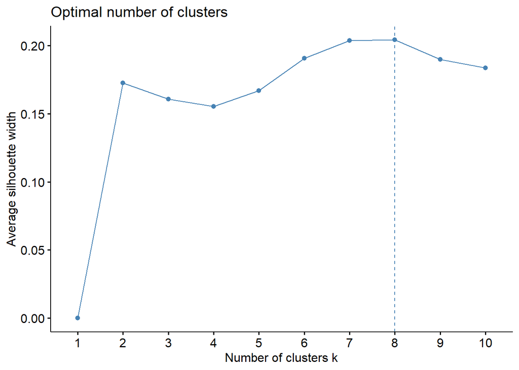

```r
# We use the mean average of the frequency of the rhetorical category among all the videos in each political-media
  # to visualize and identify these groups in regard to one another
df_ds_poli_type_gb <- group_by(df_ds_poli_type, Poli.Lean_Type) %>% summarise_all(mean)
df_ds_poli_type_gb <- df_ds_poli_type_gb %>% column_to_rownames('Poli.Lean_Type')
df_ds_poli_type_gb<- scale(as.data.frame(df_ds_poli_type_gb))

# A silhouette plot identifies the appropriate number of clusters is appropriate
fviz_nbclust(df_ds_poli_type_gb, FUN = hcut, method = "silhouette")
```

Eight clusters seems a bit high considering the only 16 total political leaning - media type groups. Lets look at the resulting dendrogram and review the clusters.

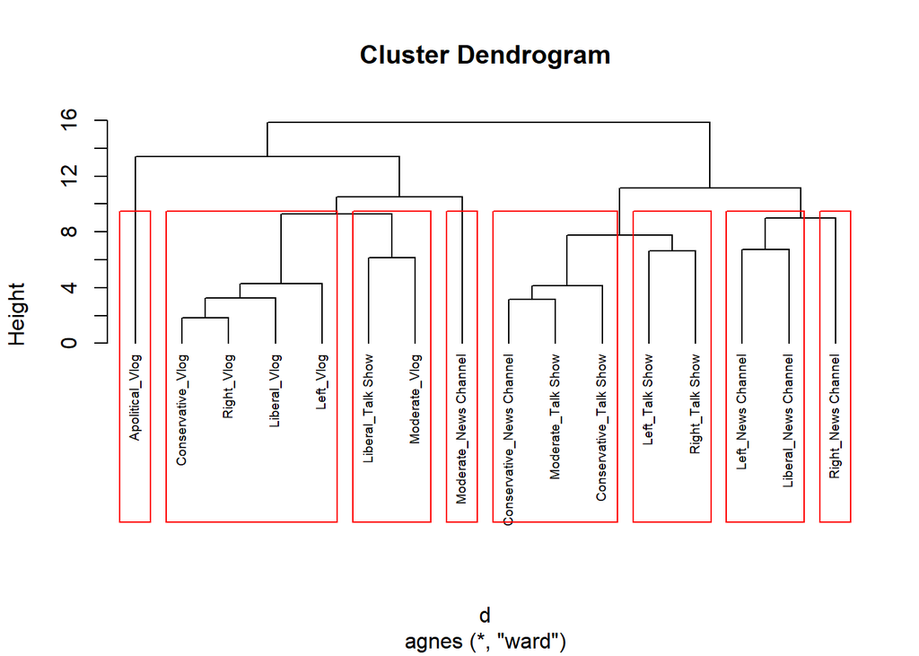

```r
d <- suppressWarnings(dist(df_ds_poli_type_gb, method = "euclidean"))
hca <- agnes(d, method = "ward")

plot(as.hclust(hca), cex = 0.6, hang = -1)
rect.hclust(hca, k = 8)
```

Next, we can visualize the euclideean distance between the political-media groups, this can provide further insight to the clustering structure.

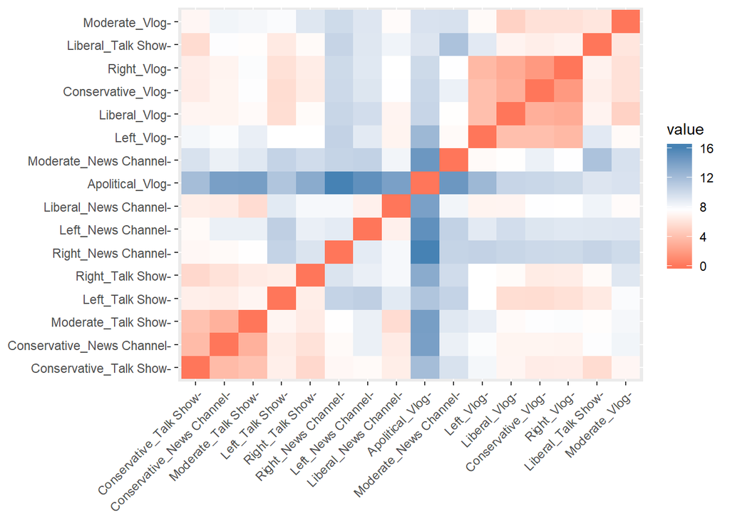

```r
ds_dist <- get_dist(df_ds_poli_type_gb)
fviz_dist(ds_dist, gradient = list(low = "tomato", mid = "white", high = "steelblue"))
```

A distance plot shows the high similarity of the Vlogs, especially the partisan charged ones. The *Moderate_Talk Show*, *Conservative_Talk Show* and *Conservative_News Channel* also have low distance, as seen in the dendrogram. However, no other obvious low distance groups appear. *Apolitical_Vlogs* appear to stand in contrast to the political media.

Next we see a similar representation in the K-means clustering as with the dendrogram clustering, using the same number of clusters.

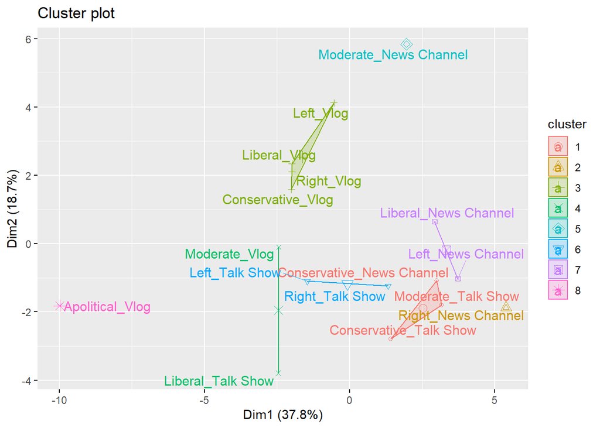

```r
km_ds <- kmeans(df_ds_poli_type_gb, centers = 8, nstart = 25)
fviz_cluster(km_ds, data = df_ds_poli_type_gb, repel=T)
```

#### MultiDimensional (MultiFactor) Analysis

As our tagging metric is zero sum by construction, we can suppose that the rhetorical tags to be correlated among each other. We can use this knowledge to create composite feature factors which can explain some of the variance of the rhetorical usage.

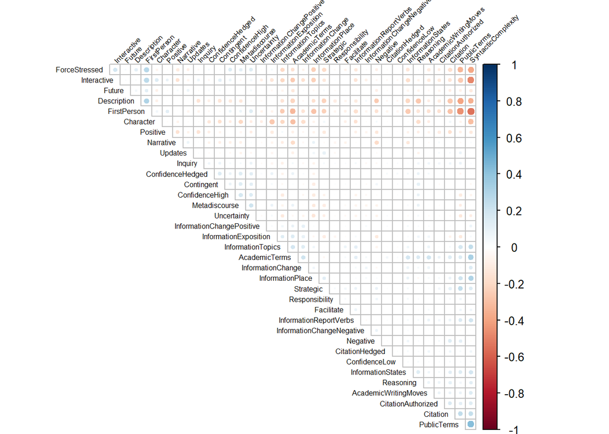

```r
# Returning to the video-level data, we can visualize a correlation plot to check if MDA is an appropriate method. Pockets of high correlation (positive or negative are suggestive of a good candidate for MDA)
m_ds <- df_ds_poli_type %>% dplyr::select(-c('Poli.Lean_Type'))
d_ds <- m_ds[, sapply(m_ds, is.numeric)]
cat_id_ds <- m_ds[, sapply(m_ds, is.factor)]
m_cor_ds <- cor(d_ds, method = "pearson")
corrplot::corrplot(m_cor_ds, type = "upper", order = "hclust",
                   tl.col = "black", tl.srt = 45, diag = F, tl.cex = 0.5)
```

Now we need to identify the appropriate number of factors to distill the rhetorical categories.

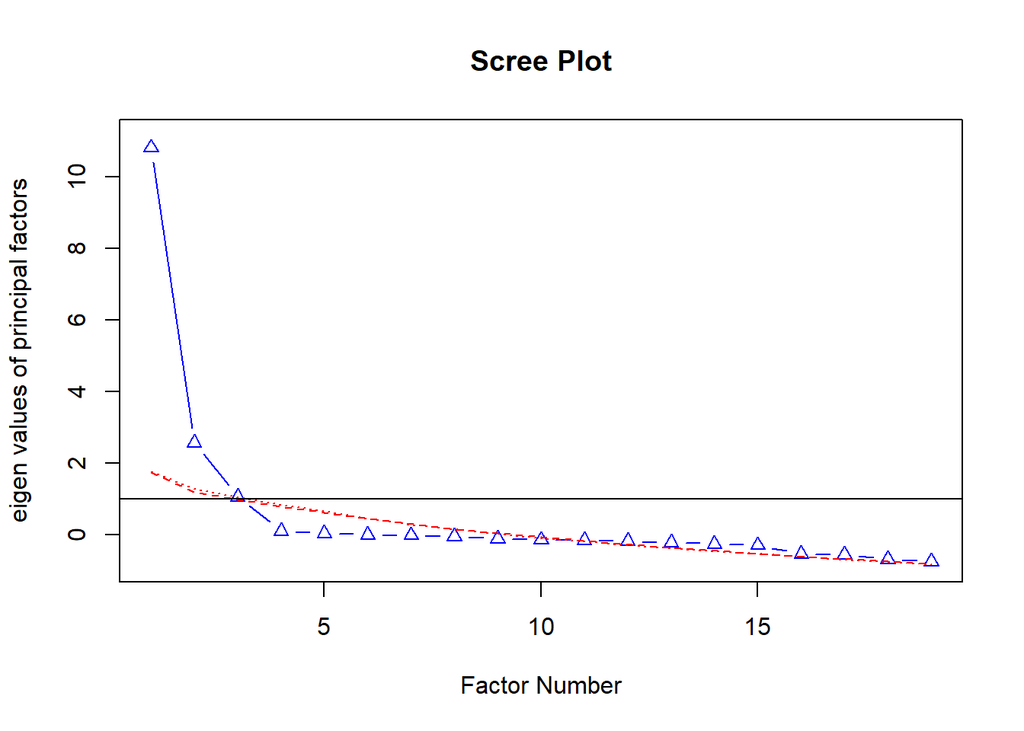

```
## Parallel analysis suggests that the number of factors =  2  and the number of components =  NA
```

```r
diag(m_cor_ds) <- 0
threshold_ds <- apply(m_cor_ds, 1, function(x) max(abs(x), na.rm = T) > .2)
m_trim_ds <-  m_cor_ds[,threshold_ds]
fa.parallel(m_trim_ds, fa="fa", main = "Scree Plot", show.legend=FALSE)
```

The Scree plot above suggests an appropriate number of factors could be two or three.

```r
# we first need to scale the rhetorical variable frequencies
df_factors <- as.data.frame(scale(df_ds_poli_type[, sapply(df_ds_poli_type, is.numeric)]))
df_factors$Poli.Lean_Type <- df_ds_poli_type$Poli.Lean_Type
# then we gather the factor loadings, the factor scores of the political-type combinations, and the explained variance from each factor.
ds_loadings <- get_loadings(df_factors, 3,  get = "loadings",thresh=.2)
ds_scores <- get_loadings(df_factors, 3, get = "scores",thresh=.2)
ds_aov <- get_loadings(df_factors, 3, get = "aov_scores",thresh=.2)
```

Next we can create a table represetning the factors, and their relative varance explantory power.

|  | Factor1 | Factor2 | Factor3 |
| --- | --- | --- | --- |
| AcademicTerms | 0.335 | 0.409 | 0.095 |
| Character | -0.23 | -0.671 | 0.15 |
| Citation | 0.276 | -0.069 | 0.158 |
| Description | -0.074 | 0.061 | -0.971 |
| ForceStressed | -0.539 | 0.111 | 0.103 |
| FirstPerson | -0.679 | -0.07 | -0.035 |
| InformationExposition | 0.002 | 0.382 | 0.014 |
| InformationChange | 0.193 | 0.235 | -0.038 |
| InformationPlace | 0.403 | -0.043 | 0.001 |
| InformationStates | 0.233 | 0.069 | 0.119 |
| InformationTopics | 0.317 | 0.209 | 0.022 |
| Interactive | -0.577 | -0.265 | 0.198 |
| Metadiscourse | -0.174 | 0.319 | 0.201 |
| Negative | 0.026 | -0.187 | 0.24 |
| PublicTerms | 0.549 | -0.099 | 0.173 |
| Reasoning | 0.026 | 0.229 | 0.257 |
| Strategic | 0.236 | -0.208 | 0.13 |
| SyntacticComplexity | 0.777 | 0.316 | 0.055 |
| Uncertainty | -0.242 | 0.166 | 0.126 |
| statistic | 1592.198 | 305.693 | 1000.952 |
| p.value | 0 | 0 | 0 |
| Rsq | 0.406 | 0.116 | 0.300 |

Next we will plot the loadings of the factors, with the highly positive components at the top and the highly negative components at the bottom, offering a somewhat coherent dimensions of analysis, for each factor.

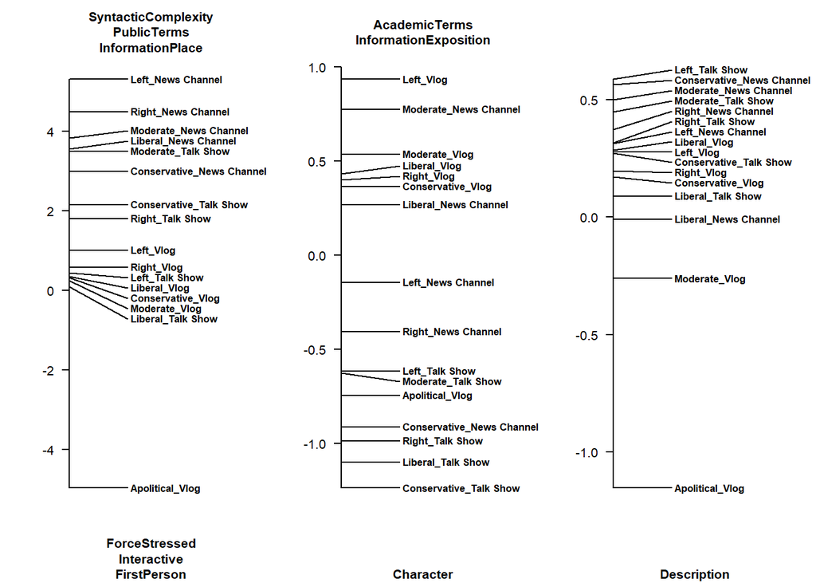

```r
par(mfrow=c(1,3))
plot_scores(ds_loadings, ds_scores, 1)
plot_scores(ds_loadings, ds_scores, 2)
plot_scores(ds_loadings, ds_scores, 3)
```

### Moral

#### Data Loading

We use the untagged transcripts in our evaluation of moral signals, and use a dictionary to tag morally loaded words with their value morality signal.

For example:

- Sacred, holy, pristine, lice, addict, vomit, plague, contagious all reflect the moral domain of purity.
- Slave, worship, elder, dictator, chief, guide, master, traitor, duty all reflect the moral domain of authority.

Though there was the possibility of using positive and negative charges of the morally loaded word, I flattened the valence to capture any identification with the moral category, as I was not able to determine towards what the morally loaded word was directed.

```r
cleaned_df <- suppressWarnings(readtext_lite(df_meta[df_meta$cleaned, 'filepath_clean']))
mfd_dict <- dictionary(file = "dictionaries/MFD2.0_no_charge.dic", tolower = F)

yt_corpus_raw <- corpus(cleaned_df)
yt_tokens_raw <- tokens(yt_corpus_raw, remove_punct = T, what = "fasterword")

# here we are only including the moral loading of tokens in our morality dictionary, and discarding the rest
toks_mfd <- tokens_lookup(yt_tokens_raw, dictionary=mfd_dict)
yt_mfd_dfm <- dfm(toks_mfd, tolower = F)


# we need to weight the moral token frequency by the total words in the transcript
df_ntokens <- data.frame(ntoken(yt_tokens_raw))
df_ntokens$document <- rownames(df_ntokens)
names(df_ntokens)[1] <- "ntokens"
yt_mfd_dfm_df <- convert(yt_mfd_dfm, to = "data.frame")
yt_mfd_dfm_df<- left_join(yt_mfd_dfm_df, df_ntokens, by='document')

# here we divide the count of the moral words by the total tokens in the transcrip
yt_mfd_dfm_df[,2:6] <- yt_mfd_dfm_df[,2:6] / yt_mfd_dfm_df[,7]

# now we combine our weighted moral words with the metadata document identifying the channel and political leaning
df_mfd <- yt_mfd_dfm_df %>% mutate(document = str_replace(document, ".txt", "")) %>%
  inner_join(dplyr::select(df_meta,'videoId','channelName','Political.Leaning','Type'),
             by=c('document'='videoId')) %>%
  mutate_if(is.character, as.factor) %>%
  mutate_if(is.numeric, ~ . * 100) %>%
  as.data.frame()
```

Next we discard outliers and full non-morally oriented transcripts. We subset our data to only consider those with at least one moral signifier.

```r
df_mfd$total <- rowSums(df_mfd[,sapply(df_mfd, is.numeric)])
# drop documents with no moral identification
df_mfd <- filter(df_mfd, total > 0) %>% dplyr::select(-total)

df_mfd <- df_mfd %>%
  dplyr::select(-ntokens, -document) %>%
  mutate(Poli.Lean_Type = as.factor(paste(Political.Leaning, Type, sep='_')))

df_moral_poli_type <- df_mfd %>%
  dplyr::select(-c('channelName','Type','Political.Leaning')) %>%
  dplyr::select('Poli.Lean_Type', everything())
```

We are going to run through a similar analysis with the moral loadings, but it seems that there is not much clustering structure to be found in the aggregated data.

##### Silhouette plot to identify peak number of clusters

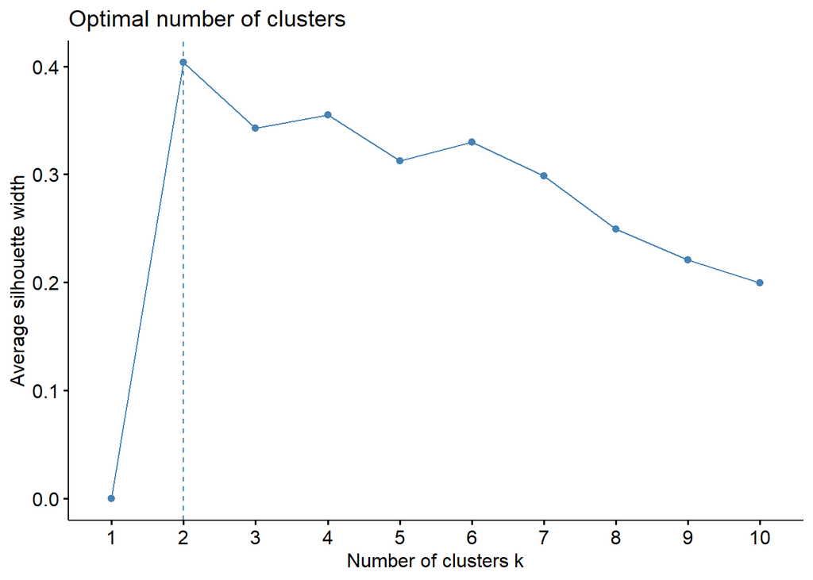

```r
df_moral_poli_type_gb <- group_by(df_moral_poli_type, Poli.Lean_Type)  %>% summarise_all(mean)
df_moral_poli_type_gb <- df_moral_poli_type_gb %>% column_to_rownames('Poli.Lean_Type')
df_moral_poli_type_gb<- scale(as.data.frame(df_moral_poli_type_gb))
fviz_nbclust(df_moral_poli_type_gb, FUN = hcut, method = "silhouette")
```

##### Cluster Dendrogram

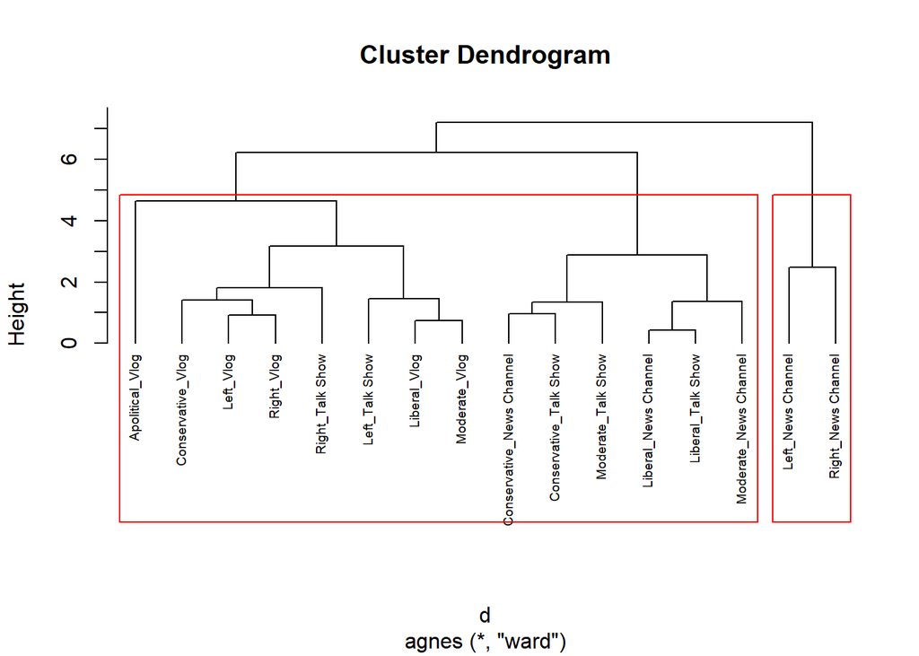

```r
d <- suppressWarnings(dist(df_moral_poli_type_gb, method = "euclidean"))
hca <- agnes(d, method = "ward")
plot(as.hclust(hca), cex = 0.6, hang = -1)
rect.hclust(hca, k = 2)
```

##### Distance Matrix

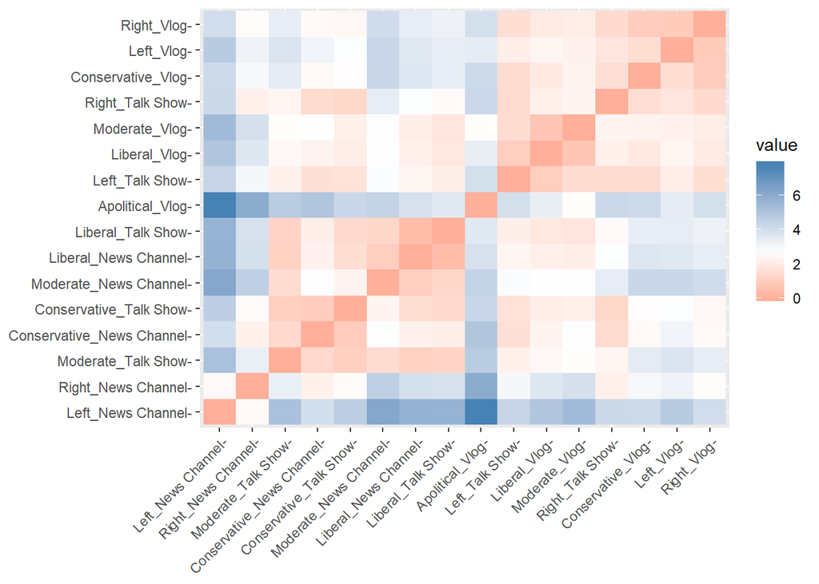

```r
moral_dist <- get_dist(df_moral_poli_type_gb)
fviz_dist(moral_dist, gradient = list(low = "tomato", mid = "white", high = "steelblue"))
```

##### K-Means visualization

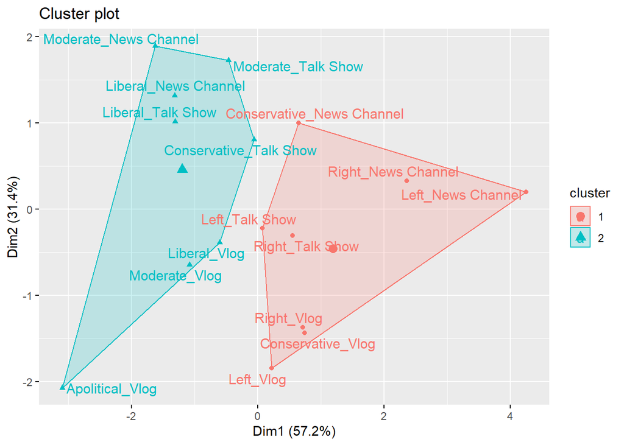

```r
km_moral <- kmeans(df_moral_poli_type_gb, centers = 2, nstart = 25)
fviz_cluster(km_moral, data = df_moral_poli_type_gb, repel=T)
```

#### Moral Keyness

Now we pivot to keyness measures of moral signaling. Keyness highlights words which occur with higher frequency between two groups of texts (a target and a reference). We use the p-value from a chi^2 test to demonstrate the statistical likelihood, and a log likelihood ratio statistic to demonstrate effect size.

```r
#df_meta<-df_meta %>% inner_join(df_ntokens%>% mutate(videoId=str_replace(document,'.txt','')) %>% dplyr::select(videoId, ntokens))
df_docvars <- filter(df_meta, cleaned == TRUE) %>% dplyr::select('channelName','Political.Leaning','Type')

yt_mfd_dfm_weighted <- dfm_weight(yt_mfd_dfm,scheme='prop')
docvars(yt_mfd_dfm_weighted) <- df_docvars

# split up the dataframe to facilitate relevant comparisons
yt_mfd_dfm_vlogs <- dfm_subset(yt_mfd_dfm_weighted, Type=='Vlog')
yt_mfd_dfm_vlogs_left_lib <- dfm_subset(yt_mfd_dfm_vlogs, Political.Leaning %in% c('Left','Liberal'))
yt_mfd_dfm_vlogs_right_cons <- dfm_subset(yt_mfd_dfm_vlogs, Political.Leaning %in% c('Conservative','Right'))
yt_mfd_dfm_vlogs_left <- dfm_subset(yt_mfd_dfm_vlogs, Political.Leaning=='Left')
yt_mfd_dfm_vlogs_right <- dfm_subset(yt_mfd_dfm_vlogs, Political.Leaning=='Right')

yt_mfd_dfm_nvlogs <- dfm_subset(yt_mfd_dfm_weighted, Type!='Vlog')
yt_mfd_dfm_nvlogs_ll <- dfm_subset(yt_mfd_dfm_nvlogs, Political.Leaning %in% c('Left','Liberal'))
yt_mfd_dfm_nvlogs_rc <- dfm_subset(yt_mfd_dfm_nvlogs, Political.Leaning %in% c('Conservative','Right'))
yt_mfd_dfm_nvlogs_left <- dfm_subset(yt_mfd_dfm_nvlogs, Political.Leaning %in% c('Left'))
yt_mfd_dfm_nvlogs_right <- dfm_subset(yt_mfd_dfm_nvlogs, Political.Leaning %in% c('Right'))

kp1 <- data.frame(keyness_pairs(yt_mfd_dfm_vlogs_left, yt_mfd_dfm_vlogs_right)[c('1_v_2_lr','1_v_2_pv')])
kp2 <- data.frame(keyness_pairs(yt_mfd_dfm_vlogs_left_lib,yt_mfd_dfm_vlogs_right_cons)[c('1_v_2_lr','1_v_2_pv')])
kp3 <- data.frame(keyness_pairs(yt_mfd_dfm_nvlogs_ll,yt_mfd_dfm_nvlogs_rc)[c('1_v_2_lr','1_v_2_pv')])
kp4 <- data.frame(keyness_pairs(yt_mfd_dfm_nvlogs_left, yt_mfd_dfm_nvlogs_right)[c('1_v_2_lr','1_v_2_pv')])
kp5 <- data.frame(keyness_pairs(yt_mfd_dfm_vlogs, yt_mfd_dfm_nvlogs)[c('1_v_2_lr','1_v_2_pv')])

kp1$feat <- rownames(kp1)
kp2$feat <- rownames(kp2)
kp3$feat <- rownames(kp3)
kp4$feat <- rownames(kp4)
kp5$feat <- rownames(kp5)

keyness_table <- inner_join(kp1,
                            inner_join(kp2,
                                       inner_join(kp4,
                                                  inner_join(kp3, kp5,by='feat'),
                                                  by='feat'),
                                       by='feat'),
                            by='feat')
names(keyness_table) <- c('Vlog.Left-Right_LogRatio','Vlog.Left-Right_P-Val',
                          'MoralFeature',
                          'Vlog.LeftLib-RightCons_LogRatio','Vlog.LeftLib-RightCons_P-Val',
                          'NonVlog.Left-Right_LogRatio','NonVlog.Left-Right_P-Val',
                          'NonVlog.LeftLib-RightCons_LogRatio','NonVlog.LeftLib-RightCons_P-Val',
                          'Vlog-NonVlog_LogRatio','Vlog-NonVlog_P-Val')


t((keyness_table %>% dplyr::select(MoralFeature, everything())))
```

```
##                                    [,1]       [,2]      [,3]       [,4]
## MoralFeature                       "sanctity" "loyalty" "fairness" "care"
## Vlog.Left-Right_LogRatio           " 0.24"    "-0.01"   "-0.05"    "-0.08"
## Vlog.Left-Right_P-Val              "0.000"    "0.841"   "0.566"    "0.129"
## Vlog.LeftLib-RightCons_LogRatio    " 0.00"    " 0.06"   "-0.10"    " 0.05"
## Vlog.LeftLib-RightCons_P-Val       "1.000"    "0.221"   "0.103"    "0.152"
## NonVlog.Left-Right_LogRatio        "-0.45"    " 0.37"   " 0.09"    " 0.32"
## NonVlog.Left-Right_P-Val           "0.010"    "0.011"   "0.655"    "0.008"
## NonVlog.LeftLib-RightCons_LogRatio "-0.18"    " 0.20"   "-0.32"    " 0.29"
## NonVlog.LeftLib-RightCons_P-Val    "0.077"    "0.022"   "0.003"    "0.000"
## Vlog-NonVlog_LogRatio              " 1.02"    "-0.17"   "-0.11"    " 0.43"
## Vlog-NonVlog_P-Val                 "0.000"    "0.000"   "0.040"    "0.000"
##                                    [,5]
## MoralFeature                       "authority"
## Vlog.Left-Right_LogRatio           "-0.12"
## Vlog.Left-Right_P-Val              "0.064"
## Vlog.LeftLib-RightCons_LogRatio    "-0.08"
## Vlog.LeftLib-RightCons_P-Val       "0.080"
## NonVlog.Left-Right_LogRatio        "-0.37"
## NonVlog.Left-Right_P-Val           "0.002"
## NonVlog.LeftLib-RightCons_LogRatio "-0.16"
## NonVlog.LeftLib-RightCons_P-Val    "0.016"
## Vlog-NonVlog_LogRatio              "-1.03"
## Vlog-NonVlog_P-Val                 "0.000"
```

The keyness table above reflects keyness comparsisons between: Left v Right Vlogs, Left/Liberal v Right/Conservative Vlogs, Left/Liberal v Righ/Conservative Non-Vlogs, Left v Right Non-Vlogs, and Vlogs vs Non-vlogs. Overall we find differences between the Left-Right and LeftLib-RightCons comparisons. The the Vlog category we see that the Left vlogs evoke Sanctity significantly more so than those on the Right. However, when also considering non-radical positions, we find the moral arugments made in Vlogs does not significantly differ from.

When only considering Left v Right, we find substantial differences in the Left’s preference for words denoting Loyalty and Care, while using Authority and Sanctity much less When also considering our more traditional domains of News Channels and Talk Shows, we find Left/Liberals to be more apt to use words related to Loyalty and Care, but not so many words related to Authority or fairness.

Overall, comparing Vlogs and Non-vlogs we see a substantial preference for Sanctity, and Care, and fewer tokens related to Authority.

## Discussion

From our MDA it seems that indeed there is rhetorical similarity among partisan vlogs, against non-partisan vlogs and non-vlog media.

It seems that rhetorical similarity is much higher within medium than within political group. This confirms our initial hypothesis, especially in consideration of the consistently clustered vlog groups. The rhetorical strategies for Left/Liberal and Right/Conservative Vlogs are similar. Upon reflection, we could conceive of this as register variation, with different media being different linguistic landscapes. Just as written media and spoken media have the peculiarities of their own media, so do Cable News, Talk Shows, and Vlogs.

Regarding the Moral signalling tokens present in our data, we find that Vlogs on the whole include less address of Authority, while more address of Sanctity and Care. There does not appear to be a difference in how Left/Liberal Vlogs use morally loaded language than Right/Conserative Vlogs, though Left seems to use Sanctity signalling morality more frequently.

## Appendix

In addition, in clustering the docuscope tagged channel level data we see a bit of the expected grouping structure.

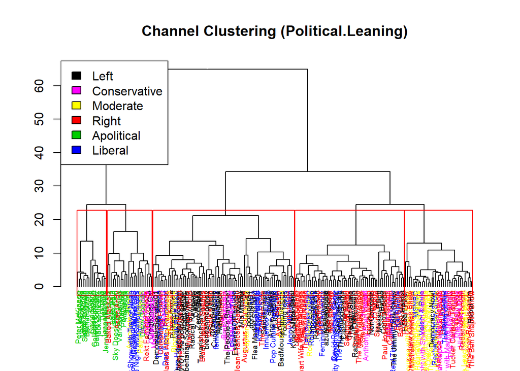

```r
# First we filter and group by relevant channle, political leaning, and media groups
df_ds_channel <- df_yt_ds %>% dplyr::select(-c('Political.Leaning','Type')) %>% dplyr::select('channelName', everything())
df_ds_channel_politype <- suppressWarnings(group_by(df_yt_ds, channelName, Type, Political.Leaning) %>% summarize_all(mean))
df_ds_channel_poli <- suppressWarnings(group_by(df_yt_ds, channelName, Political.Leaning) %>% summarize_all(mean) %>% dplyr::select(-Type))
df_ds_channel_type <- suppressWarnings(group_by(df_yt_ds, channelName, Type) %>% summarize_all(mean) %>% dplyr::select(-Political.Leaning))
df_ds_channel_gb <- suppressWarnings(group_by(df_ds_channel, channelName) %>% summarise_all(mean))

# prepare the denrogram plot outline at the channel level
d <- get_dist(df_ds_channel_gb, method = "euclidean")
hc <- hclust(d, method = "ward.D2" )
hc$labels <- df_ds_channel_gb$channelName

# create color labeling by political leaning
color_index_polt <-as.numeric(
  (arrange(df_ds_channel_poli, factor(as.character(df_ds_channel_poli$channelName),levels=labels(hc)))  %>%
     dplyr::select(Political.Leaning))[[2]])
# create color labeling by media type
color_index_type <-as.numeric(
  (arrange(df_ds_channel_type, factor(as.character(df_ds_channel_type$channelName),levels=labels(hc)))  %>%
     dplyr::select(Type))[[2]])
# plot political leanding colored dendrogram
hc %>% as.dendrogram %>%
  dendextend::set('labels_col', color_index_polt * 3)  %>%
  dendextend::set('labels_cex',.6) %>%
  plot(main="Channel Clustering (Political.Leaning)")
rect.hclust(hc, k = 5)
legend('topleft', legend=c(as.character(unique(df_ds_channel_poli$Political.Leaning))), fill=unique(as.numeric(df_ds_channel_poli$Political.Leaning) *3))
```

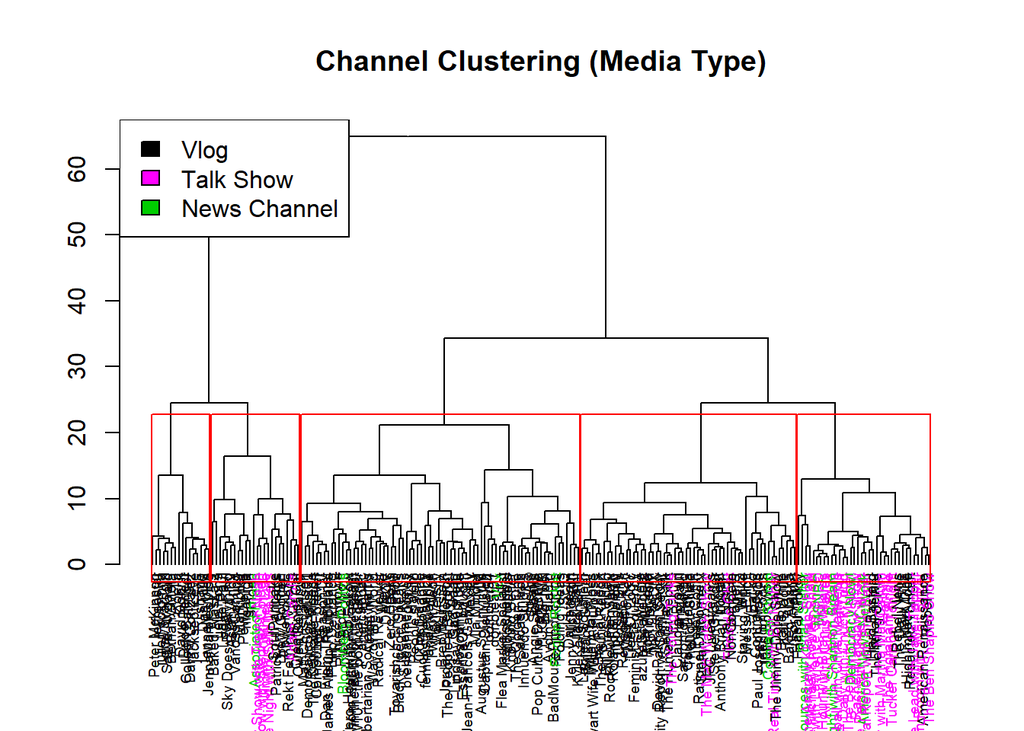

```r
# plot media type dendrogram
hc %>% as.dendrogram %>%
  dendextend::set('labels_col', color_index_type * 3)  %>%
  dendextend::set('labels_cex',.6) %>%
  plot(main="Channel Clustering (Media Type)")
rect.hclust(hc, k = 5)
legend('topleft', legend=c(as.character(unique(df_ds_channel_type$Type))), fill=unique(as.numeric(df_ds_channel_type$Type) *3))
```

In addition, we can specify to look at just the vlog content.

```r
# Filter as needed
df_ds_channel_politype_gb <- df_ds_channel_politype %>% filter(Type=='Vlog') %>% dplyr::select(-Type)
```

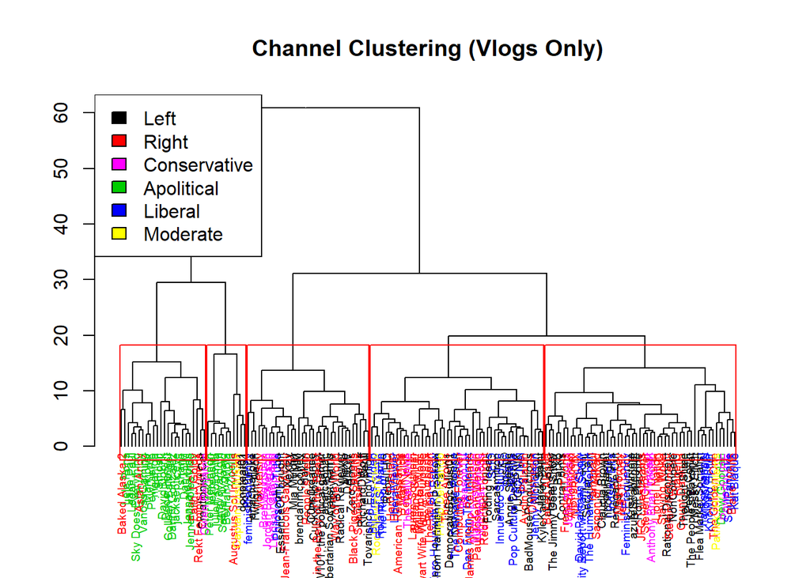

```r
# create dendrogram strucutre
d <- get_dist(df_ds_channel_politype_gb, method = "euclidean")
hc <- hclust(d, method = "ward.D2" )
hc$labels <- df_ds_channel_politype_gb$channelName

# create color index for political types of vlogs only
color_index_vlog_polt  <- as.numeric(
  (arrange(df_ds_channel_politype_gb, factor(as.character(df_ds_channel_politype_gb$channelName), levels=labels(hc))
           )  %>%
     dplyr::select(Political.Leaning))[[3]])
# Plot dendrogram of vlogs only, colored by political type
hc %>% as.dendrogram %>%
  dendextend::set('labels_col', color_index_vlog_polt * 3)  %>%
  dendextend::set('labels_cex',.6) %>%
  plot(main="Channel Clustering (Vlogs Only)")
rect.hclust(hc, k = 5)
legend('topleft', legend=c(as.character(unique(df_ds_channel_politype_gb$Political.Leaning))), fill=unique(as.numeric(df_ds_channel_politype_gb$Political.Leaning) *3))
```

### Channels Counts

| channelName | Political.Leaning | Type | words | punct | total_tokens | files |
| --- | --- | --- | --- | --- | --- | --- |
| Acronym TV | Left | Vlog | 573424 | 552 | 573976 | 286 |
| Adam Carolla | Conservative | Talk Show | 163029 | 194 | 163223 | 126 |
| All In with Chris Hayes | Moderate | Talk Show | 524097 | 57279 | 581376 | 299 |
| AltRight.com | Right | Vlog | 423652 | 342 | 423994 | 93 |
| American Renaissance | Right | Vlog | 246044 | 512 | 246556 | 118 |
| anactualjoke | Left | Vlog | 34732 | 465 | 35197 | 22 |
| anarchopac | Left | Vlog | 66192 | 39 | 66231 | 44 |
| Anderson Cooper 360 | Liberal | News Channel | 36001 | 2518 | 38519 | 86 |
| Angie Speaks | Left | Vlog | 158887 | 117 | 159004 | 18 |
| Anthony Brian Logan | Conservative | Vlog | 1839660 | 2453 | 1842113 | 322 |

[output cut: 202 more lines]